# Comparison-5-ionbot-features-tr-combo

```python
import pandas as pd
import numpy as np
import matplotlib.pyplot as plt
import seaborn as sns
from scipy import stats
import re, os, IPython, time
from pyteomics import mass
from Download_UnimodDB import Download_Unimod_Dict
unimod = Download_Unimod_Dict()
from utility_functions import *
DATE
```

```
'20250627'
```

```python
my_palette = [project_palette['trembl'], project_palette['openprot']]
```

```python
working_folder = "C:/Users/Enrico/OneDrive - UGent/run-ionbot"
PXDs = ["PXD002057.v0.11.4","PXD005833.v0.11.4","PXD014258.v0.11.4"]
# filtering = 'custom'
filtering = 'hybrid'
```

```python
combo = []
for dataset_name in PXDs:
    combo.append(pd.read_csv(os.path.join(working_folder, dataset_name, f'openprot-x-trembl-filt-{filtering}.csv')))
combo = pd.concat(combo, ignore_index=True)
```

```python
print(combo.shape)
combo = combo[combo.matched_peptide_open==combo.matched_peptide_open].copy(deep=True)
print(combo.shape)
combo['by-count-norm_trembl'] = combo['by-count_trembl'] / combo.matched_peptide_trembl.apply(len)
combo['by-count-norm_open']   = combo['by-count_open'] / combo.matched_peptide_open.apply(len)
combo['y-count-norm_trembl']  = combo['y-count_trembl'] / combo.matched_peptide_trembl.apply(len)
combo['y-count-norm_open']    = combo['y-count_open'] / combo.matched_peptide_open.apply(len)
combo['b-count-norm_trembl']  = combo['b-count_trembl'] / combo.matched_peptide_trembl.apply(len)
combo['b-count-norm_open']    = combo['b-count_open'] / combo.matched_peptide_open.apply(len)
print(combo.shape)
```

```
(312313, 66)
(312313, 66)
(312313, 72)
```

```python
## keep only one modified peptide when 2 are possible
combo.modifications_trembl = combo.modifications_trembl.fillna('').apply(lambda x: x.split('_or_')[0])
combo.modifications_open   = combo.modifications_open.fillna('').apply(lambda x: x.split('_or_')[0])
```

#### Comparing specific subgroups

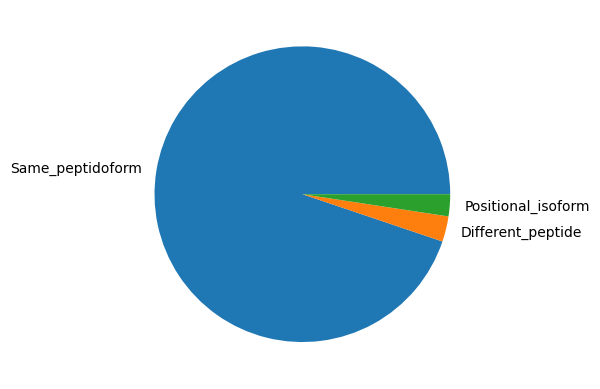

```python
def samepep_and_samemod(row):
    if row.Same_peptide and row.Same_mods_noRT:
        return 'Same_peptidoform'
    elif row.Same_peptide and not row.Same_mods_noRT:
        return 'Positional_isoform'
    elif not row.Same_peptide and not row.Same_mods_noRT:
        return 'Different_peptide'

combo['samepep_samemod'] = combo.apply(samepep_and_samemod, axis=1)

y = combo['samepep_samemod'].value_counts()
plt.pie(y, labels=y.index)
plt.show()
```

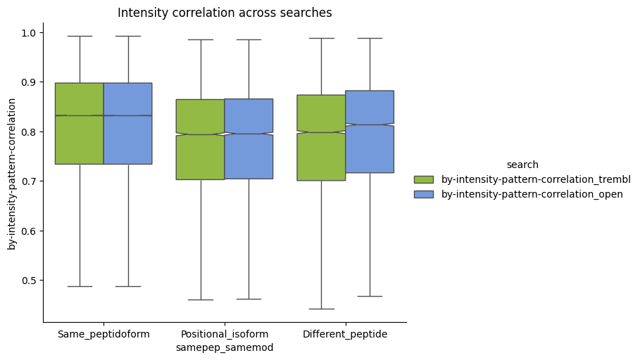

```python
VAR = 'samepep_samemod'
ORDER = ['Same_peptidoform','Positional_isoform','Different_peptide']

tmp = combo.melt(id_vars=['spectrum_title','scan','spectrum_file',VAR],
                           value_vars=['by-intensity-pattern-correlation_trembl',
                                       'by-intensity-pattern-correlation_open'],
                           var_name='search', value_name='value')
sns.catplot(data=tmp, kind='box', x=VAR, y='value', hue='search', aspect=1.25, showfliers=False, notch=True,
            palette=my_palette, order=ORDER)
plt.title('Intensity correlation across searches')
plt.ylabel('by-intensity-pattern-correlation')
# sns.catplot(data=tmp, kind='point', x=VAR, y='value', hue='search', linestyle='none', dodge=True, aspect=1.25,
#             palette=my_palette, order=ORDER)
# plt.title('Intensity correlation across searches')
# plt.ylabel('by-intensity-pattern-correlation')
plt.show()
```

```python
VAR, VAL = 'samepep_samemod','by-intensity-pattern-correlation'
for i,df in combo.groupby(VAR).__iter__():
    _,pval = stats.mannwhitneyu(df[f'{VAL}_trembl'],
                                df[f'{VAL}_open'])
    print(f'{i} p={pval:.1e} {pval<.05}')
print('\n')
for i,df in combo.groupby(VAR).__iter__():
    _,pval = stats.wilcoxon(df[f'{VAL}_trembl'],
                                df[f'{VAL}_open'])
    print(f'{i} p={pval:.1e} {pval<.05}')
print('\n')
for i,df in combo.groupby(VAR).__iter__():
    print(f'{i}', cohenD(df[f'{VAL}_trembl'],df[f'{VAL}_open']))
```

```
Different_peptide p=3.5e-11 True
Positional_isoform p=5.2e-01 False
Same_peptidoform p=9.3e-01 False


Different_peptide p=3.1e-101 True
Positional_isoform p=2.5e-02 True
Same_peptidoform p=0.0e+00 True


Different_peptide 0.106
Positional_isoform 0.01
Same_peptidoform 0.0
```

```python
combo['target_decoy'] = combo.apply(lambda row: f'{row.database_trembl}->{row.database_open}', axis=1)
combo.target_decoy.value_counts()
# counts too low!
```

```
target_decoy
T->T    310789
D->D       879
T->D       332
D->T       313
Name: count, dtype: int64
```

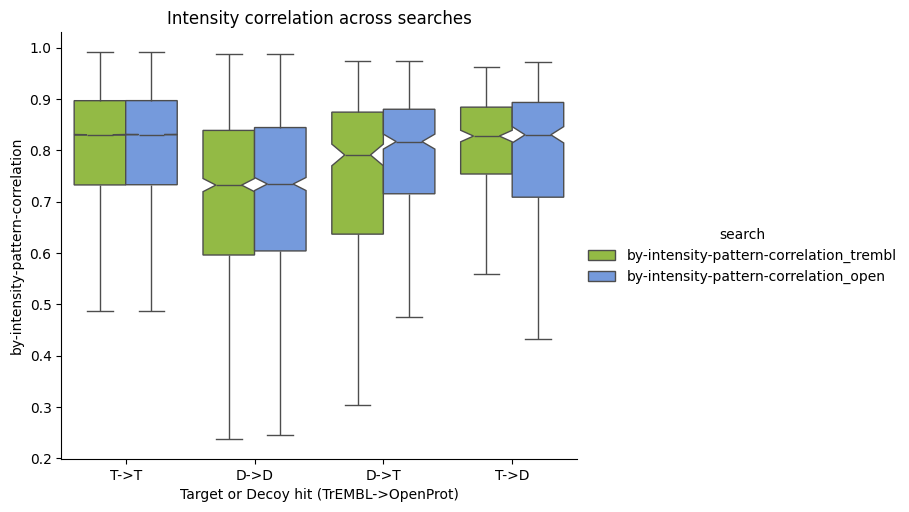

```python
tmp = combo.melt(id_vars=['spectrum_title','scan','spectrum_file','target_decoy'],
                           value_vars=['by-intensity-pattern-correlation_trembl',
                                       'by-intensity-pattern-correlation_open'],
                           var_name='search', value_name='value')

sns.catplot(data=tmp, kind='box',   x='target_decoy', y='value', hue='search',
            aspect=1.25, showfliers=False, notch=True, palette=my_palette, order=['T->T','D->D','D->T','T->D'])
plt.title('Intensity correlation across searches')
plt.xlabel('Target or Decoy hit (TrEMBL->OpenProt)')
plt.ylabel('by-intensity-pattern-correlation')

# sns.catplot(data=tmp, kind='point', x='target_decoy', y='value', hue='search',
#             linestyle='none', aspect=1.25, dodge=True, palette=my_palette, order=['T->T','D->D','D->T','T->D'])
# plt.title('Intensity correlation across searches')
# plt.xlabel('Canonical protein hit (trEMBL->OpenProt)')
# plt.ylabel('by-intensity-pattern-correlation')
plt.savefig(os.path.join('publication-data', f'by-ions-trembl-openprot-2-{filtering}.svg'), dpi=300, bbox_inches='tight')
```

```python
VAR, VAL = 'target_decoy','by-intensity-pattern-correlation'
for i,df in combo.groupby(VAR).__iter__():
    _,pval = stats.mannwhitneyu(df[f'{VAL}_trembl'],
                                df[f'{VAL}_open'])
    print(f'{i} p={pval:.1e} {pval<.05}')
print('\n')
for i,df in combo.groupby(VAR).__iter__():
    _,pval = stats.wilcoxon(df[f'{VAL}_trembl'],
                                df[f'{VAL}_open'])
    print(f'{i} p={pval:.1e} {pval<.05}')
print('\n')
for i,df in combo.groupby(VAR).__iter__():
    print(f'{i}', cohenD(df[f'{VAL}_trembl'],df[f'{VAL}_open']))
```

```
D->D p=5.0e-01 False
D->T p=2.9e-02 True
T->D p=5.8e-01 False
T->T p=3.2e-01 False


D->D p=2.6e-03 True
D->T p=3.0e-03 True
T->D p=3.7e-01 False
T->T p=0.0e+00 True


D->D 0.031
D->T 0.257
T->D 0.166
T->T 0.003
```

```python
combo['canon_before_after'] = combo.apply(lambda row: f'{row.isCanonical_trembl}->{row.isCanonical_open}', axis=1)
combo.canon_before_after.value_counts(sort=False)
```

```
canon_before_after
Canonical->Canonical       309514
Canonical->NonCanonical      2799
Name: count, dtype: int64
```

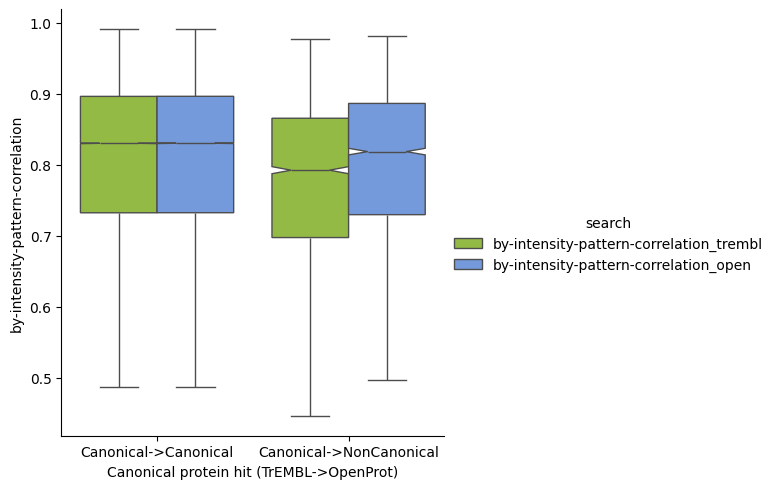

```python
VAR, VAL =  'canon_before_after', 'by-intensity-pattern-correlation',
tmp = combo.melt(id_vars=['spectrum_title','scan','spectrum_file',VAR],
                       value_vars=[f'{VAL}_trembl',f'{VAL}_open'],
                       var_name='search', value_name='value')

sns.catplot(data=tmp, kind='box', x=VAR, y='value', hue='search', showfliers=False,
            notch=True, palette=my_palette,
           )
plt.xlabel('Canonical protein hit (TrEMBL->OpenProt)')
# plt.xticks(rotation=90)
plt.ylabel(VAL)

# sns.catplot(data=tmp, kind='point', x=VAR, y='value', hue='search', linestyle='none', dodge=True,
#             palette=my_palette,
#            )
# plt.xlabel('Canonical protein hit (UniProt->OpenProt)')
# plt.xticks(rotation=90)
# plt.ylabel(VAL)

# plt.show()
plt.savefig(os.path.join('publication-data', f'by-ions-trembl-openprot-1-{filtering}.svg'), dpi=300, bbox_inches='tight')
```

```python
VAR, VAL =  'canon_before_after', 'by-intensity-pattern-correlation',
for i,df in combo.groupby(VAR).__iter__():
    _,pval = stats.mannwhitneyu(df[f'{VAL}_trembl'],
                                df[f'{VAL}_open'])
    print(f'{i} p={pval:.1e} {pval<.05}')
print('\n')
for i,df in combo.groupby(VAR).__iter__():
    _,pval = stats.wilcoxon(df[f'{VAL}_trembl'],
                                df[f'{VAL}_open'])
    print(f'{i} p={pval:.1e} {pval<.05}')
print('\n')
for i,df in combo.groupby(VAR).__iter__():
    print(f'{i}', cohenD(df[f'{VAL}_trembl'],df[f'{VAL}_open']))
```

```
Canonical->Canonical p=7.4e-01 False
Canonical->NonCanonical p=2.7e-16 True


Canonical->Canonical p=0.0e+00 True
Canonical->NonCanonical p=2.4e-131 True


Canonical->Canonical 0.001
Canonical->NonCanonical 0.226
```

```python
autosave(extra_labels='-'+filtering)
filtering
```